# MGT6203_HW3_P2

## Setup

Import the necessary libraries and datasets

```r
library(pROC)
library(caret)
library(dplyr)
```

```r
library(ggplot2)
install.packages("e1071")
kag <- read.csv("KAG.csv", stringsAsFactors = FALSE)
ads <- read.csv('advertising (1).csv', stringsAsFactors=FALSE)
ads$Clicked.on.Ad <- as.factor(ads$Clicked.on.Ad)
```

## Q1. a

ad_id 1121094 had the least CPC (0.0) with 24362 Impressions

```r
arrange(kag,CPC,desc(Impressions))[1:1,]
```

```
##     X   ad_id campaign_id age gender interest Impressions Clicks Spent
## 1 521 1121094        1178  32      0       10       24362      0     0
##   Total_Conversion Approved_Conversion CTR CPC CostPerConv_Total
## 1                1                   1   0   0                 0
##   CostPerConv_Approved
## 1                    0
```

## Q1. b

ad_id 738637 spent the least efficiently with 1.5 CPM and 944 impressions

```r
kag$CPM <- round(1000*kag$Spent/kag$Impressions, 2)
arrange(kag,desc(CPM))[1:1,]
```

```
##     X  ad_id campaign_id age gender interest Impressions Clicks Spent
## 1 151 738637         936  47      1       24         944      1  1.42
##   Total_Conversion Approved_Conversion    CTR  CPC CostPerConv_Total
## 1                1                   0 0.1059 1.42              1.42
##   CostPerConv_Approved CPM
## 1                 1.42 1.5
```

## Q2

Calculate ROAS (Return on advertising spent) and round it to two decimals

```r
kag$ROAS <- round((10*kag$Total_Conversion + 50*kag$Approved_Conversion)/kag$Spent,2)
```

## Q2. a

Make a boxplot grouped by gender for interest_id = 15, 21, 101

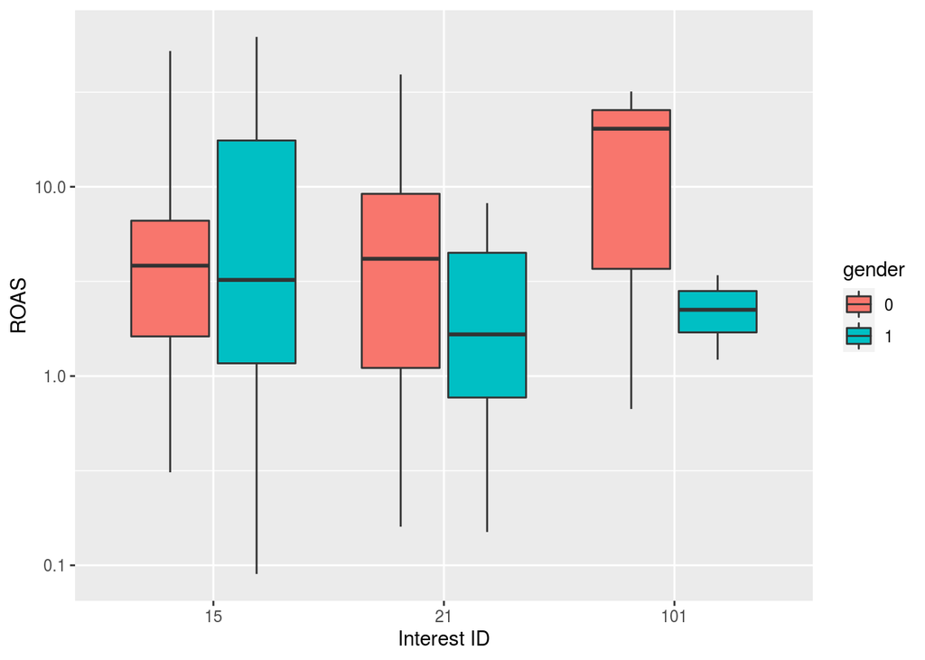

```r
kag2 <- filter(kag,interest %in% c('15','21','101'))
ggplot(data = kag2, aes(x=as.factor(interest), y=ROAS)) +
  geom_boxplot(aes(fill=as.factor(gender))) + xlab("Interest ID") +
  ylab("ROAS") + scale_y_log10() + labs(fill = "gender")
```

## Q2. b

Median and mean of ROAS by genders when campign_id == 1178

```r
kag3 <- filter(kag,campaign_id == 1178,Spent!=0.00)
kag3 %>% group_by(gender) %>% summarise(Mean = mean(ROAS), Median = median(ROAS))
```

```
## # A tibble: 2 x 3
##   gender  Mean Median
##    <int> <dbl>  <dbl>
## 1      0  3.14   1.59
## 2      1  1.92   0.92
```

## Q3

Make a scatter plot for Daily.Internet.Usage against Age. Separate the datapoints by different shapes and/or color based on if the datapoint has clicked on the ad or not. Based off the general trends in the scatter plot you created, consider a new data point where an individual has a Daily.Internet.Usage less than or equal to 150, and an age of 40. Would this new individual be likely to click the ad or not click the ad? [5 points]

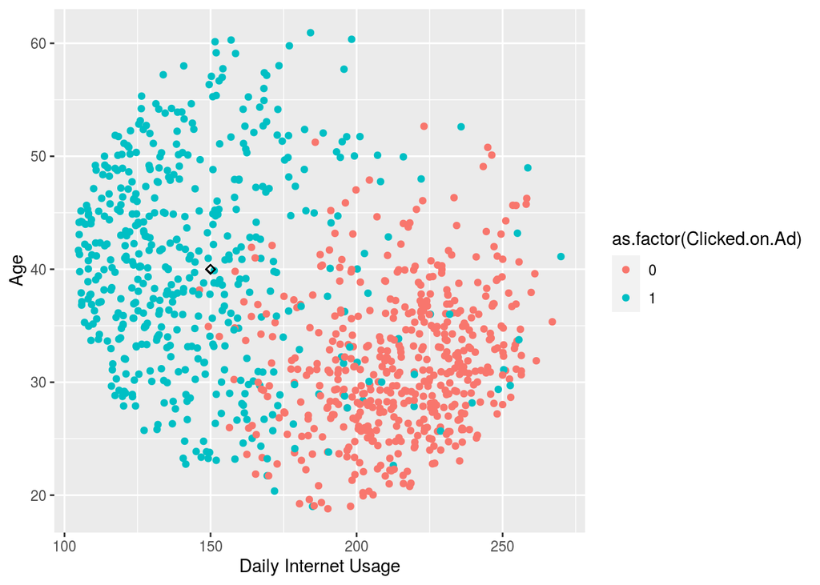

```r
ggplot(data=ads, aes(x=Daily.Internet.Usage,y=Age))+
  geom_jitter(aes(colour=as.factor(Clicked.on.Ad))) + xlab("Daily Internet Usage") +
  ylab("Age") + geom_point(aes(x=150, y=40), colour="black",pch=5)
```

## Q4

Create a logistic regression model using the variables ‘Daily.Time.Spent.on.Site’, ‘Age’, and ‘Area.Income’ to predict the variable ‘Clicked.on.Ad’. Display the summary output of this logistic regression model.

```r
q4model <- glm(Clicked.on.Ad~ Daily.Time.Spent.on.Site+Age+Area.Income,data=ads,family=binomial)
summary(q4model)
```

```
##
## Call:
## glm(formula = Clicked.on.Ad ~ Daily.Time.Spent.on.Site + Age +
##     Area.Income, family = binomial, data = ads)
##
## Deviance Residuals:
##      Min        1Q    Median        3Q       Max
## -2.59567  -0.30198  -0.06632   0.09470   2.84467
##
## Coefficients:
##                            Estimate Std. Error z value Pr(>|z|)
## (Intercept)               1.504e+01  1.443e+00  10.420   <2e-16 ***
## Daily.Time.Spent.on.Site -2.048e-01  1.565e-02 -13.085   <2e-16 ***
## Age                       1.630e-01  1.785e-02   9.132   <2e-16 ***
## Area.Income              -1.173e-04  1.274e-05  -9.206   <2e-16 ***
## ---
## Signif. codes:  0 '***' 0.001 '**' 0.01 '*' 0.05 '.' 0.1 ' ' 1
##
## (Dispersion parameter for binomial family taken to be 1)
##
##     Null deviance: 1386.29  on 999  degrees of freedom
## Residual deviance:  391.98  on 996  degrees of freedom
## AIC: 399.98
##
## Number of Fisher Scoring iterations: 7
```

## Q5

Given the output below, 87 false negative occurrences were observed

```r
ads$pred = predict(q4model,new.data=ads,type = "response")
ads$ClickPred = ifelse(ads$pred>=.8,1,0)
result <- table(ads$Clicked.on.Ad,ads$ClickPred)
confusionMatrix(result)
```

```
## Confusion Matrix and Statistics
##
##
##       0   1
##   0 488  12
##   1  87 413
##
##                Accuracy : 0.901
##                  95% CI : (0.8808, 0.9188)
##     No Information Rate : 0.575
##     P-Value [Acc > NIR] : < 2.2e-16
##
##                   Kappa : 0.802
##
##  Mcnemar's Test P-Value : 1.028e-13
##
##             Sensitivity : 0.8487
##             Specificity : 0.9718
##          Pos Pred Value : 0.9760
##          Neg Pred Value : 0.8260
##              Prevalence : 0.5750
##          Detection Rate : 0.4880
##    Detection Prevalence : 0.5000
##       Balanced Accuracy : 0.9102
##
##        'Positive' Class : 0
##
```

```r
r <- roc(ads,Clicked.on.Ad,ClickPred)
r
```

```
##
## Call:
## roc.data.frame(data = ads, response = Clicked.on.Ad, predictor = ClickPred)
##
## Data: ClickPred in 500 controls (Clicked.on.Ad 0) < 500 cases (Clicked.on.Ad 1).
## Area under the curve: 0.901
```

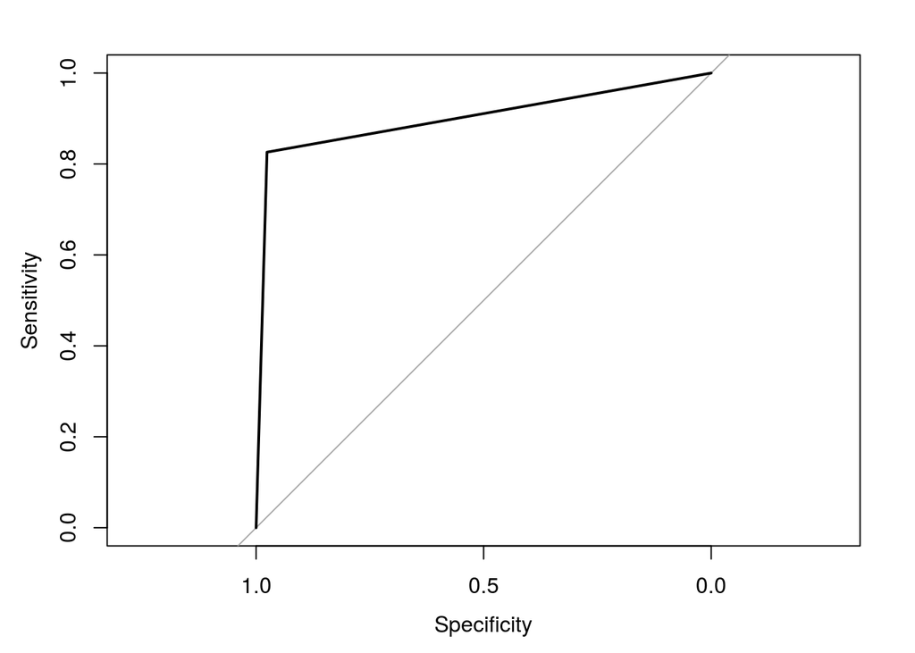

```r
plot(r)
```

## Q6

The average amount of time customers will wait in line under the current restaurant scenario is 7 minutes (rounding to the nearest integer)

```r
lambda <- 62 # customers per hour - arrival rate
mew1 <- 70 # customers per hour - service rate
Lq1 <- (lambda^2)/(mew1*(mew1-lambda))
Wq1 <- Lq1/lambda
Wq1*60
```

```
## [1] 6.642857
```

## Q6. b

The average number of customers that would be waiting in the queue would be 2 (rounded to the nearest integer)

```r
mew2 <- 84 # customers per hour - service rate
Lq2 <- (lambda^2)/(mew2*(mew2-lambda))
Lq2
```

```
## [1] 2.080087
```

## Q7

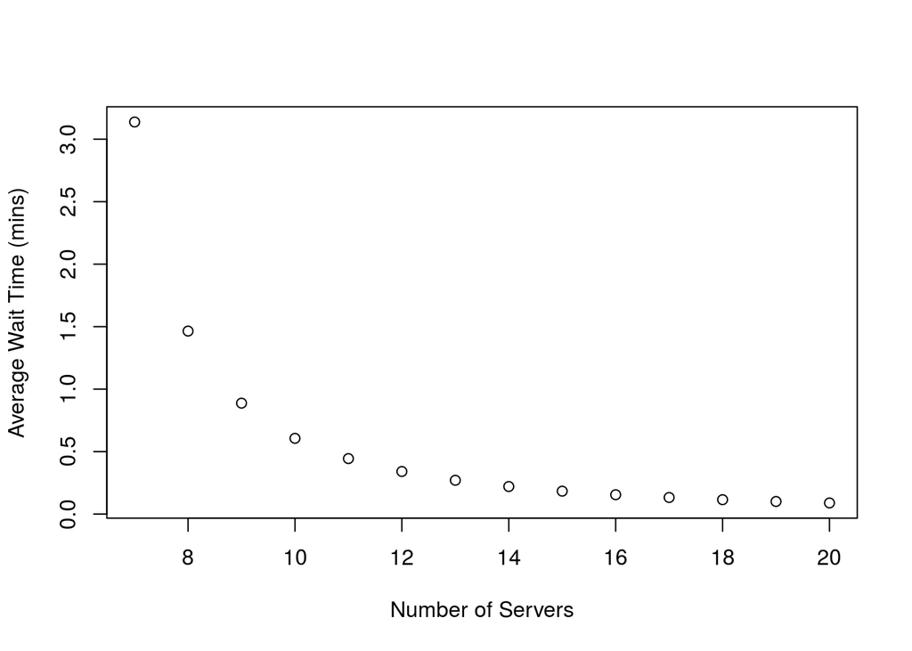

```r
lambda2 <- ((7:20*14)*0)+82 # customers per hour - arrival rate
Servers <- 7:20
mew3 <- 7:20*14 # customers per hour - service rate
Lq3 <- (lambda2^2)/(mew3*(mew3-lambda2))
Wq3 <- (Lq3/lambda2)*60
plot(x=Servers,y=Wq3,xlab = "Number of Servers",ylab="Average Wait Time (mins)")
```

## Q8 a

Based on the plot above, the average customer wait time drops below 3 minutes with 8 servers.

## Q8 b

Based on the plot above, the average customer wait time decreases with additional servers. The most drastic change occurs adding 1 server (from 7 to 8), which reduces the wait time by about a half. The most optimal staffing would be at 10 servers at the curve’s “elbow.” As the number of servers reaches infinity, the average wait time approaches zero.